# Предсказание цены на автомобили. Семинар по SL и ML: экзамен.

# Введение

Используем три различных метода построения модели

1. Линейная регрессия
2. Random forest
3. Нейронная сеть

и сравним полученные результаты.

# Описание данных и чистка

Начнём с библиотек.

```r
#install.packages(c("knitr", "kableExtra", "magick",
#                   "ggplot2", "reshape2", "viridis",
#                   "stringr", "FactoMineR", "factorextra",
#                   "kohonen", "mclust", "dbscan", "easyr", "fastDummies"))
library(knitr)
library(kableExtra) #красивые html таблицы
library(magick)     #работа с картинками
library(ggplot2)    #графики
library(reshape2)   #работа с датафреймом
library(viridis)    #палитра
library(stringr)    #работа с текстом
library(FactoMineR) #факторный анализ
library(factoextra) #факторный анализ
library(easyr)
library(fastDummies)
library(GGally)
library(randomForest)
library(tree)
library(neuralnet)
```

Данные, которые мы используем, взяты по ссылке отсюда: https://www.kaggle.com/lepchenkov/usedcarscatalog.

Это данные объявлений на продажу автомобилей в Белоруссии в декабре 2019 года. Задачу для себя мы поставим следующим образом: предсказать цену автомобиля на основании его характеристик.

Читаем датасет из csv файла и смотрим на его размерность.

```r
cars <- read.csv("cars.csv") #полный датафрейм
cbind(before = dim(cars), after_na_rm = dim(cars <- na.omit(cars)))
```

```
##      before after_na_rm
## [1,]  38531       38521
## [2,]     30          30
```

Как можно видеть, размер у датасета немаленький и вполне достаточный для того, чтобы дать возможность “проявить” себя всем рассматриваемым методам.

```r
names(cars)
```

```
##  [1] "manufacturer_name" "model_name"        "transmission"
##  [4] "color"             "odometer_value"    "year_produced"
##  [7] "engine_fuel"       "engine_has_gas"    "engine_type"
## [10] "engine_capacity"   "body_type"         "has_warranty"
## [13] "state"             "drivetrain"        "price_usd"
## [16] "is_exchangeable"   "location_region"   "number_of_photos"
## [19] "up_counter"        "feature_0"         "feature_1"
## [22] "feature_2"         "feature_3"         "feature_4"
## [25] "feature_5"         "feature_6"         "feature_7"
## [28] "feature_8"         "feature_9"         "duration_listed"
```

Относительно переменных: по словам автора датасета, переменные `feature_0`-`feature_9` не имеют описания и характеризуют некоторые технические детали. Ввиду неполноты информации, мы вынуждены изъять их из рассмотрения.

```r
cars <- cars[,-(20:29)]
```

Среди численных переменных видим `odometer_value`, `year_produced`, `engine_capacity`, `price_usd`, `number_of_photos`, `up_counter`, `duration_listed` (7 переменных).

```r
dummy_cands <- c("transmission", "has_warranty", "is_exchangeable", "manufacturer_name", "color", "engine_fuel", "engine_type", "body_type", "state", "drivetrain", "location_region")
#apply(cars[,dummy_cands], MARGIN = 2, FUN = unique)
```

Сделаем dummy variables из всего, кроме марки (их многовато).

```r
dummy_cands <- dummy_cands[-which(dummy_cands == "manufacturer_name")]
cars_dum <- dummy_cols(cars, select_columns = dummy_cands, remove_most_frequent_dummy = TRUE)
cars_dum <- cars_dum[,!(names(cars_dum) %in% dummy_cands)]
```

```r
dim(cars_dum)
```

```
## [1] 38521    49
```

```r
names(cars_dum)
```

```
##  [1] "manufacturer_name"                "model_name"
##  [3] "odometer_value"                   "year_produced"
##  [5] "engine_has_gas"                   "engine_capacity"
##  [7] "price_usd"                        "number_of_photos"
##  [9] "up_counter"                       "duration_listed"
## [11] "transmission_automatic"           "has_warranty_True"
## [13] "is_exchangeable_True"             "color_blue"
## [15] "color_brown"                      "color_green"
## [17] "color_grey"                       "color_orange"
## [19] "color_other"                      "color_red"
## [21] "color_silver"                     "color_violet"
## [23] "color_white"                      "color_yellow"
## [25] "engine_fuel_diesel"               "engine_fuel_gas"
## [27] "engine_fuel_hybrid-diesel"        "engine_fuel_hybrid-petrol"
## [29] "engine_type_diesel"               "body_type_cabriolet"
## [31] "body_type_coupe"                  "body_type_hatchback"
## [33] "body_type_liftback"               "body_type_limousine"
## [35] "body_type_minibus"                "body_type_minivan"
## [37] "body_type_pickup"                 "body_type_suv"
## [39] "body_type_universal"              "body_type_van"
## [41] "state_emergency"                  "state_new"
## [43] "drivetrain_all"                   "drivetrain_rear"
## [45] "location_region_Брестская обл."   "location_region_Витебская обл."
## [47] "location_region_Гомельская обл."  "location_region_Гродненская обл."
## [49] "location_region_Могилевская обл."
```

Зафиксируем индексы марки, модели, и признаки, которые дублируют остальные и которые не будут использованы в моделировании.

```r
extraneous_vars <- c(1,2,29,34,26,27)
```

После добавления dummy variables переменных стало больше, но их количество вполне можно считать допустимым для построения модели при текущем размере выборки.

## Разбиение на тренировочную и тестовую выборку

Возьмём тестовую выборку как $1/5$ от всей выборки.

```r
set.seed(10001)
N <- 6000
cars_dum <- cars_dum[sample(1:nrow(cars_dum), N, replace = FALSE),]
test_id <- sample(1:N, N/5, replace = FALSE)
train_id <- (1:N)[-test_id]
```

Длина тренировочной выборки: 4800, Длина тестовой выборки: 1200.

# Линейная регрессия

```r
start_time <- Sys.time()
lm.car <- lm(price_usd~., data = cars_dum[,-extraneous_vars], subset = train_id)
end_time <- Sys.time()
end_time - start_time
```

```
## Time difference of 0.02453804 secs
```

```r
summary(lm.car)
```

```
##
## Call:
## lm(formula = price_usd ~ ., data = cars_dum[, -extraneous_vars],
##     subset = train_id)
##
## Residuals:
##    Min     1Q Median     3Q    Max
## -10280  -1698   -276   1206  35042
##
## Coefficients:
##                                      Estimate Std. Error t value Pr(>|t|)
## (Intercept)                        -7.512e+05  1.647e+04 -45.616  < 2e-16 ***
## odometer_value                     -5.061e-03  4.309e-04 -11.745  < 2e-16 ***
## year_produced                       3.768e+02  8.199e+00  45.960  < 2e-16 ***
## engine_has_gasTrue                 -7.868e+02  2.641e+02  -2.979 0.002904 **
## engine_capacity                     9.815e+02  9.807e+01  10.008  < 2e-16 ***
## number_of_photos                    9.550e+01  8.560e+00  11.156  < 2e-16 ***
## up_counter                          3.838e-01  1.641e+00   0.234 0.815076
## duration_listed                     9.395e-01  5.747e-01   1.635 0.102197
## transmission_automatic              1.163e+03  1.367e+02   8.510  < 2e-16 ***
## has_warranty_True                   3.502e+02  8.013e+02   0.437 0.662124
## is_exchangeable_True               -2.465e+02  1.047e+02  -2.355 0.018582 *
## color_blue                         -5.219e+02  1.722e+02  -3.031 0.002451 **
## color_brown                         1.034e+03  3.610e+02   2.863 0.004210 **
## color_green                        -5.616e+02  2.189e+02  -2.566 0.010329 *
## color_grey                          3.418e+02  1.928e+02   1.773 0.076336 .
## color_orange                       -7.202e+02  7.105e+02  -1.014 0.310860
## color_other                        -1.628e+02  2.144e+02  -0.759 0.447647
## color_red                          -8.364e+01  2.069e+02  -0.404 0.686041
## color_silver                       -6.042e+02  1.607e+02  -3.761 0.000171 ***
## color_violet                       -4.897e+01  4.513e+02  -0.109 0.913603
## color_white                         7.043e+02  1.931e+02   3.646 0.000269 ***
## color_yellow                       -8.665e+02  5.422e+02  -1.598 0.110078
## engine_fuel_diesel                  1.005e+03  1.200e+02   8.375  < 2e-16 ***
## `engine_fuel_hybrid-petrol`         2.197e+03  7.180e+02   3.060 0.002225 **
## body_type_cabriolet                 2.270e+03  1.064e+03   2.133 0.032946 *
## body_type_coupe                     1.408e+03  3.975e+02   3.543 0.000400 ***
## body_type_hatchback                -6.043e+02  1.471e+02  -4.107 4.07e-05 ***
## body_type_liftback                  3.848e+02  4.643e+02   0.829 0.407236
## body_type_minibus                   2.398e+03  2.801e+02   8.559  < 2e-16 ***
## body_type_minivan                  -5.198e+01  1.838e+02  -0.283 0.777361
## body_type_pickup                    2.705e+03  8.046e+02   3.362 0.000780 ***
## body_type_suv                       1.903e+03  2.139e+02   8.897  < 2e-16 ***
## body_type_universal                -2.877e+02  1.601e+02  -1.797 0.072377 .
## body_type_van                       9.202e+02  3.784e+02   2.432 0.015068 *
## state_emergency                    -1.105e+03  5.335e+02  -2.071 0.038408 *
## state_new                           1.001e+04  8.298e+02  12.069  < 2e-16 ***
## drivetrain_all                      2.452e+03  2.123e+02  11.548  < 2e-16 ***
## drivetrain_rear                     1.412e+03  1.641e+02   8.602  < 2e-16 ***
## `location_region_Брестская обл.`   -1.187e+02  1.878e+02  -0.632 0.527521
## `location_region_Витебская обл.`   -4.754e+02  1.834e+02  -2.592 0.009564 **
## `location_region_Гомельская обл.`  -4.593e+02  1.857e+02  -2.473 0.013446 *
## `location_region_Гродненская обл.`  2.952e+01  1.980e+02   0.149 0.881467
## `location_region_Могилевская обл.` -3.084e+02  1.895e+02  -1.627 0.103797
## ---
## Signif. codes:  0 '***' 0.001 '**' 0.01 '*' 0.05 '.' 0.1 ' ' 1
##
## Residual standard error: 3331 on 4757 degrees of freedom
## Multiple R-squared:  0.7067, Adjusted R-squared:  0.7041
## F-statistic: 272.9 on 42 and 4757 DF,  p-value: < 2.2e-16
```

```r
lm.car_predict <- predict(lm.car, cars_dum[test_id,-extraneous_vars])
lm.train_err <- sqrt(mean(lm.car$residuals^2))
lm.test_err <- sqrt(mean((lm.car_predict - cars_dum$price_usd[test_id])^2))
cbind((lm.train_err), (lm.test_err))
```

```
##          [,1]     [,2]
## [1,] 3315.739 3540.138
```

## С логарифмированием

```r
start_time <- Sys.time()
lm_log.car <- lm(log(price_usd)~., data = cars_dum[,-extraneous_vars], subset = train_id)
end_time <- Sys.time()
end_time - start_time
```

```
## Time difference of 0.02455688 secs
```

```r
summary(lm_log.car)
```

```
##
## Call:
## lm(formula = log(price_usd) ~ ., data = cars_dum[, -extraneous_vars],
##     subset = train_id)
##
## Residuals:
##     Min      1Q  Median      3Q     Max
## -8.1249 -0.2137  0.0409  0.2577  6.0906
##
## Coefficients:
##                                      Estimate Std. Error t value Pr(>|t|)
## (Intercept)                        -1.630e+02  2.384e+00 -68.360  < 2e-16 ***
## odometer_value                     -4.406e-07  6.239e-08  -7.063 1.87e-12 ***
## year_produced                       8.523e-02  1.187e-03  71.801  < 2e-16 ***
## engine_has_gasTrue                 -1.290e-01  3.824e-02  -3.374 0.000745 ***
## engine_capacity                     2.276e-01  1.420e-02  16.031  < 2e-16 ***
## number_of_photos                    1.226e-02  1.239e-03   9.891  < 2e-16 ***
## up_counter                         -6.968e-04  2.376e-04  -2.933 0.003375 **
## duration_listed                     3.788e-04  8.321e-05   4.553 5.42e-06 ***
## transmission_automatic              1.735e-01  1.979e-02   8.770  < 2e-16 ***
## has_warranty_True                  -6.517e-02  1.160e-01  -0.562 0.574320
## is_exchangeable_True               -5.971e-02  1.516e-02  -3.939 8.30e-05 ***
## color_blue                         -7.984e-02  2.493e-02  -3.203 0.001370 **
## color_brown                         5.255e-02  5.227e-02   1.005 0.314736
## color_green                        -1.071e-01  3.169e-02  -3.379 0.000733 ***
## color_grey                          1.727e-02  2.792e-02   0.619 0.536103
## color_orange                       -4.844e-02  1.029e-01  -0.471 0.637722
## color_other                        -4.470e-02  3.104e-02  -1.440 0.149885
## color_red                          -1.403e-01  2.995e-02  -4.685 2.88e-06 ***
## color_silver                       -5.199e-02  2.326e-02  -2.235 0.025479 *
## color_violet                       -2.730e-01  6.534e-02  -4.178 2.99e-05 ***
## color_white                        -1.261e-01  2.796e-02  -4.509 6.66e-06 ***
## color_yellow                       -1.977e-01  7.850e-02  -2.519 0.011805 *
## engine_fuel_diesel                  2.009e-01  1.738e-02  11.562  < 2e-16 ***
## `engine_fuel_hybrid-petrol`         2.775e-01  1.040e-01   2.669 0.007632 **
## body_type_cabriolet                 7.172e-01  1.541e-01   4.655 3.33e-06 ***
## body_type_coupe                     2.730e-01  5.755e-02   4.743 2.16e-06 ***
## body_type_hatchback                -1.150e-01  2.130e-02  -5.401 6.97e-08 ***
## body_type_liftback                  6.347e-02  6.721e-02   0.944 0.345034
## body_type_minibus                   3.832e-01  4.056e-02   9.449  < 2e-16 ***
## body_type_minivan                   1.820e-01  2.661e-02   6.840 8.90e-12 ***
## body_type_pickup                    5.729e-01  1.165e-01   4.918 9.06e-07 ***
## body_type_suv                       1.897e-01  3.096e-02   6.128 9.63e-10 ***
## body_type_universal                -2.722e-02  2.318e-02  -1.175 0.240247
## body_type_van                       3.114e-01  5.479e-02   5.684 1.39e-08 ***
## state_emergency                    -1.113e+00  7.724e-02 -14.415  < 2e-16 ***
## state_new                           3.347e-01  1.201e-01   2.786 0.005359 **
## drivetrain_all                      1.801e-01  3.074e-02   5.858 5.01e-09 ***
## drivetrain_rear                     1.957e-01  2.376e-02   8.239 2.23e-16 ***
## `location_region_Брестская обл.`    1.893e-02  2.719e-02   0.696 0.486333
## `location_region_Витебская обл.`   -1.749e-02  2.655e-02  -0.659 0.510001
## `location_region_Гомельская обл.`  -5.147e-02  2.689e-02  -1.914 0.055687 .
## `location_region_Гродненская обл.`  5.372e-04  2.866e-02   0.019 0.985048
## `location_region_Могилевская обл.`  9.806e-03  2.744e-02   0.357 0.720860
## ---
## Signif. codes:  0 '***' 0.001 '**' 0.01 '*' 0.05 '.' 0.1 ' ' 1
##
## Residual standard error: 0.4822 on 4757 degrees of freedom
## Multiple R-squared:  0.7811, Adjusted R-squared:  0.7792
## F-statistic: 404.2 on 42 and 4757 DF,  p-value: < 2.2e-16
```

```r
lm_log.car_predict <- predict(lm_log.car, cars_dum[test_id,-extraneous_vars])
lm_log.train_err <- sqrt(mean((exp(lm_log.car$fitted.values) - cars_dum$price_usd[train_id])^2))
lm_log.test_err <- sqrt(mean((exp(lm_log.car_predict) - cars_dum$price_usd[test_id])^2))
cbind((lm_log.train_err), (lm_log.test_err))
```

```
##          [,1]   [,2]
## [1,] 2566.806 2830.5
```

Если взглянуть на попарные корреляции, явной проблемы мультиколлинеарности мы не наблюдаем.

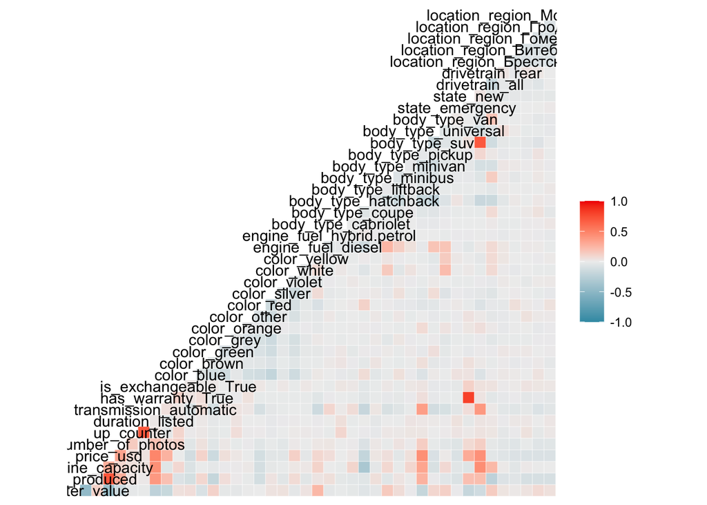

```r
ggcorr(cars_dum[train_id,-extraneous_vars])
```

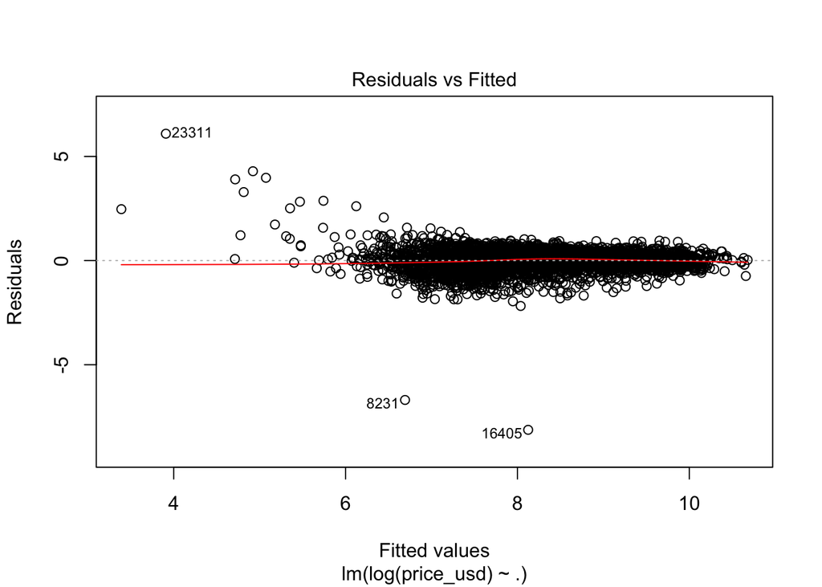

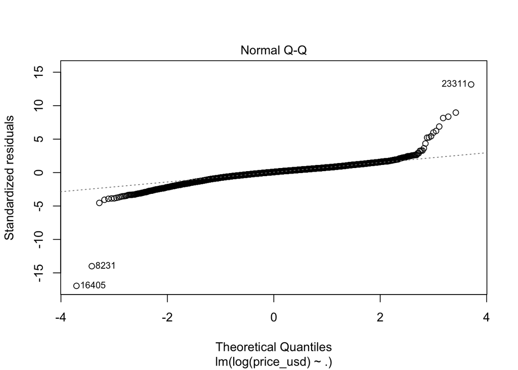

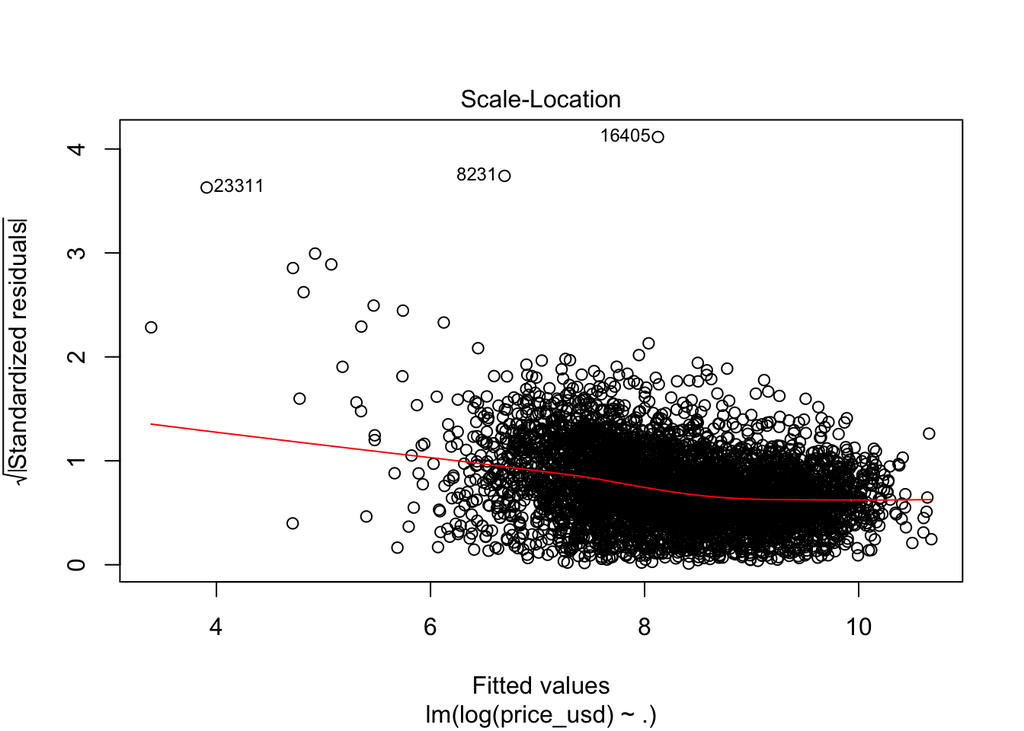

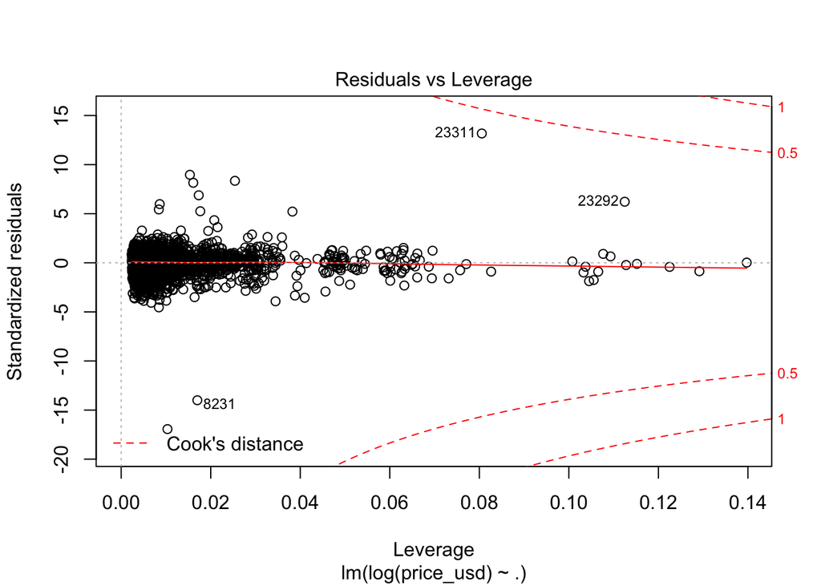

```r
plot(lm_log.car)
```

## Про метод

1. **Какая постановка задачи, что предполагается, что и почему оптимизируется (функция потерь), как оптимизируется?**
2. **Какие параметры у метода: функция плюс соответствие теор.формул и параметров**
3. **Как подбирали параметры, на основе чего?**
4. **Как справлялись с overfitting?**
5. **Какой получили результат на cross-validation?**
6. **Подтверждаете свое исходное объяснение, почему метод сработал хорошо/плохо**

# Random Forest

Параметр `mtry` отвечает за число переменных, которое выбирается из всего набора для построения дерева

`nodesize` это параметр, который отвечает за минимальное число элементов внутри узла. Когда это значение достигается, дерево перестаёт расти.

```r
set.seed(999)
valid_size <- 1000
valid_id <- sample(1:length(train_id), valid_size)
ntrees <- 500
# start_time <- Sys.time()
# rf.car <- randomForest(x = data.frame(cars_dum[train_id[-valid_id],-c(7,extraneous_vars)]),
#                        y = cars_dum$price_usd[train_id[-valid_id]],
#                        ntree = ntrees,
#                        mtry = 30, #44 params total, std is p/3
#                        nodesize = 3,
#                        importance = TRUE,
#                        ytest = cars_dum$price_usd[test_id],
#                        xtest = data.frame(cars_dum[test_id,-c(7,extraneous_vars)]))
# end_time <- Sys.time()
# end_time - start_time
#saveRDS(rf.car, "rf_car.rds")
rf.car <- readRDS("rf_car.rds")
```

Построим графики квадратного корня из MSE для различного числа деревьев.

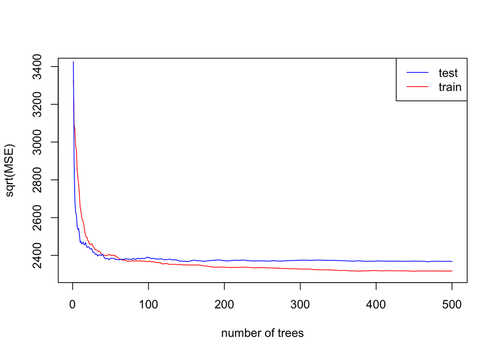

```r
plot(1:ntrees, rf.train_err <- sqrt(rf.car$mse), type="l", xlab = "number of trees", ylab="sqrt(MSE)", col="red", ylim = c(2300, 3400))
lines(1:ntrees, rf.test_err <- sqrt(rf.car$test$mse), type="l", col="blue")
legend("topright", legend = c("test","train"), lty = c(1,1), col = c("blue", "red"))
```

```r
rf.train_err <- tail(rf.train_err, 1)
rf.test_err <- tail(rf.test_err, 1)
```

Посмотрим, где достигается минимум тренировочной ошибки.

```r
which.min(rf.car$mse)
```

```
## [1] 451
```

Разница между результатами невелика:

```r
sqrt(rf.car$mse[100]) - sqrt(rf.car$mse[which.min(rf.car$mse)])
```

```
## [1] 51.96373
```

Ещё одна полезная оценка - псевдо-коэффициент детерминации (ещё одна возможность сравнить с линейной регрессией)

```r
rf.car$rsq[100]
```

```
## [1] 0.8555632
```

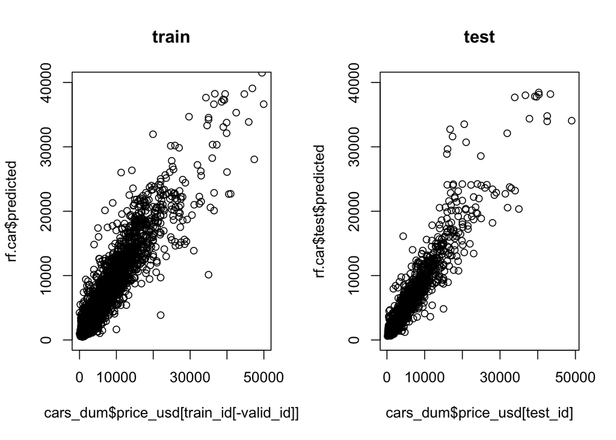

```r
par(mfrow = c(1,2))
plot(cars_dum$price_usd[train_id[-valid_id]], rf.car$predicted, main = "train", ylim = c(0,40000))
plot(cars_dum$price_usd[test_id], rf.car$test$predicted, main = "test", ylim = c(0,40000))
```

Также можем обратить внимание на значимость переменных и чистоту узлов.

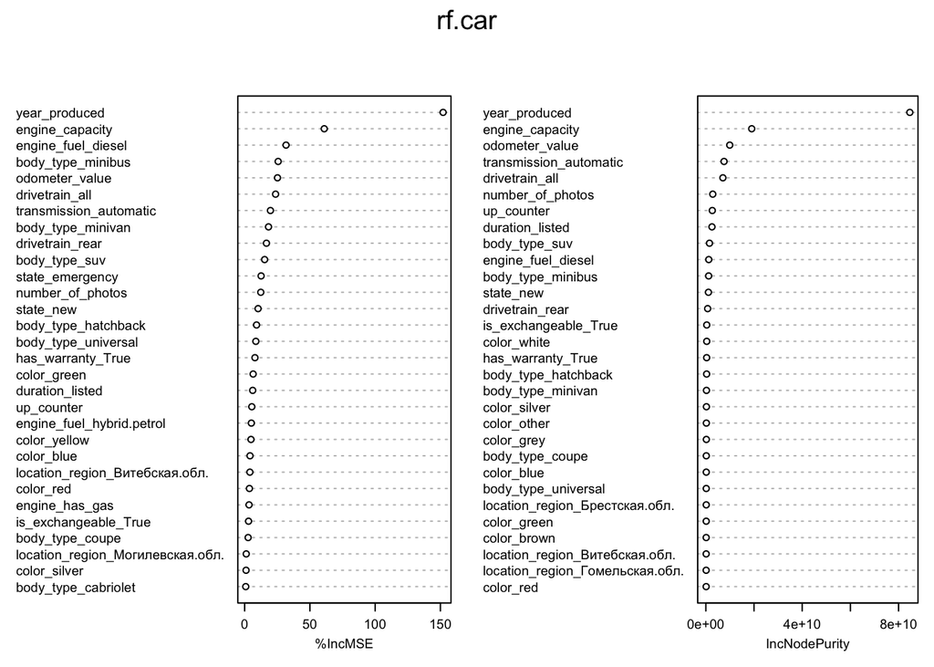

```r
varImpPlot(rf.car, cex = 0.6)
```

## Дополнительные эксперименты

### Число признаков: `mtry`

```r
set.seed(99669)
ntrees <- 500
#start_time <- Sys.time()
mt_s <- rep(seq(5, 40, 5),3)
# mse_train_mtry <- numeric(length = length(mt_s))
# mse_valid_mtry <- numeric(length = length(mt_s))
# mse_valid_curves_mtry <- list(length = length(mt_s))
# wh_min_mtry <- numeric(length = length(mt_s))
# for (i in 1:length(mt_s)) {
# rf.car_mtry <- randomForest(x = data.frame(cars_dum[train_id[-valid_id],-c(7,extraneous_vars)]),
#                        y = cars_dum$price_usd[train_id[-valid_id]],
#                        ntree = ntrees,
#                        mtry = mt_s[i], #44 params total, std is p/3
#                        nodesize = 5,
#                        importance = TRUE,
#                        ytest = cars_dum$price_usd[train_id[valid_id]],
#                        xtest = data.frame(cars_dum[train_id[valid_id],-c(7,extraneous_vars)]))
# mse_train_mtry[i] <- sqrt(tail(rf.car_mtry$mse, 1))
# mse_valid_mtry[i] <- sqrt(tail(rf.car_mtry$test$mse, 1))
# mse_valid_curves_mtry[[i]] <- sqrt(rf.car_mtry$test$mse)
# wh_min_mtry[i] <- which.min(abs(rf.car_mtry$mse - median(rf.car_mtry$mse)))
# }
# end_time <- Sys.time()
# end_time - start_time

# saveRDS(mse_train_mtry, "mse_train_mtry.rds")
# saveRDS(mse_valid_mtry, "mse_valid_mtry.rds")
# saveRDS(mse_valid_curves_mtry, "mse_valid_curves_mtry.rds")
# saveRDS(wh_min_mtry, "wh_min_mtry.rds")
#
mse_train_mtry <- readRDS("mse_train_mtry.rds")
mse_valid_mtry <- readRDS("mse_valid_mtry.rds")
mse_valid_curves_mtry <- readRDS("mse_valid_curves_mtry.rds")
wh_min_mtry <- readRDS("wh_min_mtry.rds")
```

[figure not shown]

```r
plot(mt_s, mse_train_mtry, col = "red", ylim = c(2000, 2800), main = "mtry parameter tuning", pch = 4, xlab = "mtry value", ylab = "sqrt(MSE)")
points(mt_s, mse_valid_mtry, col = "blue", pch = 4)
legend("topright", legend = c("validation","train"), pch = 4, col = c("red", "blue"))
```

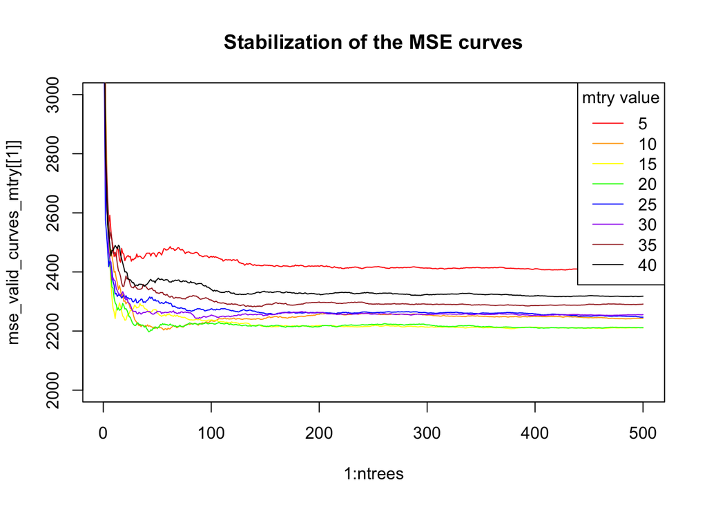

```r
plot(1:ntrees, mse_valid_curves_mtry[[1]], "l", ylim = c(2000, 3000), col = "red", main = "Stabilization of the MSE curves")
lines(1:ntrees, mse_valid_curves_mtry[[2]], col = "orange")
lines(1:ntrees, mse_valid_curves_mtry[[3]], col = "yellow")
lines(1:ntrees, mse_valid_curves_mtry[[4]], col = "green")
lines(1:ntrees, mse_valid_curves_mtry[[5]], col = "blue")
lines(1:ntrees, mse_valid_curves_mtry[[6]], col = "purple")
lines(1:ntrees, mse_valid_curves_mtry[[7]], col = "brown")
lines(1:ntrees, mse_valid_curves_mtry[[8]], col = "black")
legend("topright", legend = mt_s[1:8], title = "mtry value", lty = rep(1,8), col = c("red", "orange", "yellow", "green", "blue", "purple", "brown", "black"))
```

### Глубина дерева: `nodesize`

```r
set.seed(99669)
ntrees <- 500
#start_time <- Sys.time()
node_s <- rep(c(1,3,5,10,20,35,50),3)
# mse_train_node <- numeric(length = length(node_s))
# mse_valid_node <- numeric(length = length(node_s))
# wh_min_node <- numeric(length = length(node_s))
# for (i in 1:length(node_s)) {
# rf.car_node <- randomForest(x = data.frame(cars_dum[train_id[-valid_id],-c(7,extraneous_vars)]),
#                        y = cars_dum$price_usd[train_id[-valid_id]],
#                        ntree = ntrees,
#                        mtry = 30, #44 params total, std is p/3
#                        nodesize = node_s[i],
#                        importance = TRUE,
#                        ytest = cars_dum$price_usd[train_id[valid_id]],
#                        xtest = data.frame(cars_dum[train_id[valid_id],-c(7,extraneous_vars)]))
# mse_train_node[i] <- sqrt(tail(rf.car_node$mse, 1))
# mse_valid_node[i] <- sqrt(tail(rf.car_node$test$mse, 1))
# wh_min_node[i] <- which.min(abs(rf.car_node$mse - median(rf.car_node$mse)))
# }
# end_time <- Sys.time()
# end_time - start_time

# saveRDS(mse_train_node, "mse_train_node.rds")
# saveRDS(mse_valid_node, "mse_valid_node.rds")
# saveRDS(wh_min_node, "wh_min_node.rds")
#
mse_train_node <- readRDS("mse_train_node.rds")
mse_valid_node <- readRDS("mse_valid_node.rds")
wh_min_node <- readRDS("wh_min_node.rds")
```

[figure not shown]

```r
plot(node_s, mse_train_node, col = "red", ylim = c(2000, 2600), main = "nodesize parameter tuning", pch = 4, xlab = "nodesize value", ylab = "sqrt(MSE)")
points(node_s, mse_valid_node, col = "blue", pch = 4)
legend("topright", legend = c("validation","train"), pch = 4, col = c("red", "blue"))
```

## Про метод

1. **Какая постановка задачи, что предполагается, что и почему оптимизируется (функция потерь), как оптимизируется?**

Задача регрессии, оптимизируем квадратичную функцию потерь. Основа метода: применение решающих деревьев на бутстреп выборках и сокращённом числе признаков.

2. **Какие параметры у метода: функция плюс соответствие теор.формул и параметров**

Главные параметры: `mtry` и `nodesize`.

3. **Как подбирали параметры, на основе чего?**

4. **Как справлялись с overfitting?**

Смотрим на стабилизацию, рассчитываем на усреднение. Обычно для этого контролируется `nodesize`, но у нас такой проблемы не было.

5. **Какой получили результат на cross-validation?**

Можно посмотреть выше.

6. **Подтверждаете свое исходное объяснение, почему метод сработал хорошо/плохо**

Хорошо сработал averaging по деревьям.

# Нейронная сеть

```r
cars_dum$engine_has_gas <- as.integer(as.logical(cars_dum$engine_has_gas))
maxs <- as.numeric(apply(cars_dum[,-extraneous_vars], 2, max))
mins <- as.numeric(apply(cars_dum[,-extraneous_vars], 2, min))
means <- as.numeric(apply(cars_dum[,-extraneous_vars], 2, mean))
scaled_cars <- as.data.frame(scale(as.matrix(cars_dum[,-extraneous_vars]), center = mins,
                              scale = maxs - mins))
names(scaled_cars) <- paste("n",1:ncol(scaled_cars), sep = "")
scaled_cars_train <- as.data.frame(scaled_cars[train_id[-valid_id],])
scaled_cars_valid <- as.data.frame(scaled_cars[train_id[valid_id],])
scaled_cars_test <- as.data.frame(scaled_cars[test_id,])
```

## Один скрытый слой

```r
# set.seed(4537)
#
# start_time <- Sys.time()
#
# #works but slow, hmmm
 relu = function(x) {
     (x + abs(x))/2
     }
 epochs <- 20
# nn1.car <- neuralnet(n5 ~ .,
#                 data = scaled_cars_train,
#                 algorithm = "rprop+",
#                 hidden = 10,
#                 stepmax = 1e+05,
#                 linear.output = TRUE,
#                 act.fct = "logistic",
#                 err.fct = "sse",
#                 startweights = NULL,
#                 rep = epochs,
#                 threshold = 0.2
#                 )
# end_time <- Sys.time()
# end_time - start_time

#saveRDS(nn1.car, "nn1_car.rds")
nn1.car <- readRDS("nn1_car.rds")
```

```r
nn1.test_prediction <- list(length = epochs)
nn1.test_err_curve <- numeric(length = epochs)
nn1.train_err_curve <- numeric(length = epochs)

for (i in 1:epochs) {
pr.nn <- predict(nn1.car, scaled_cars_test[,-5], rep = i)
nn1.test_prediction[[i]] <- pr.nn * (maxs[5] - mins[5]) + mins[5]
nn1.test_err_curve[i] <- sqrt(mean((cars_dum$price_usd[test_id] - nn1.test_prediction[[i]])^2))
nn1.train_err_curve[i] <- sqrt(mean(((nn1.car$net.result[[i]] * (maxs[5] - mins[5]) ) + mins[5] - cars_dum[train_id[-valid_id], 7])^2))
}
```

### Learning curve

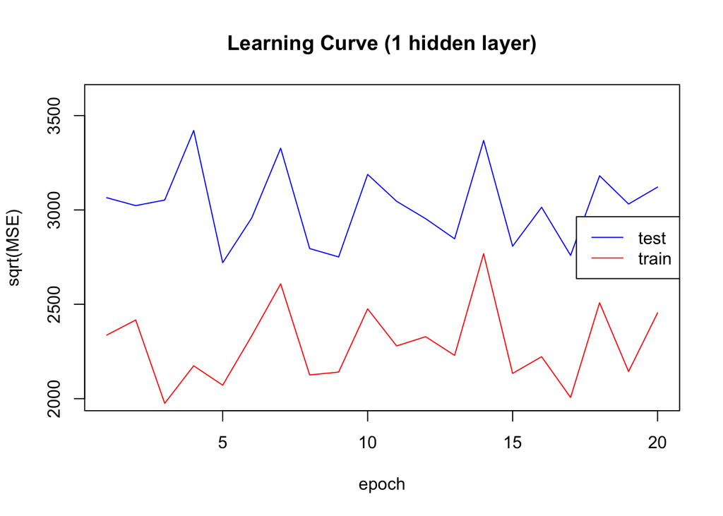

```r
plot(1:epochs, nn1.test_err_curve, col = "blue", main = "Learning Curve (1 hidden layer)", xlab = "epoch", ylab = "sqrt(MSE)", ylim = c(2000,3600), "l")
lines(1:epochs, nn1.train_err_curve, col = "red")
legend("right", legend = c("test","train"), lty = c(1,1), col = c("blue", "red"))
```

```r
nn1.train_err <- nn1.train_err_curve[15]
nn1.test_err <- nn1.test_err_curve[15]
```

### Дополнительные эксперименты

#### Число нейронов

Узнаём на validation set и по одной эпохе.

```r
set.seed(44537)
epochs <- 1
neur_seq <- rep(c(5,10,20,40), 3)
# mse_valid_neur <- numeric(length = length(neur_seq))
# mse_test_neur <- numeric(length = length(neur_seq))
#
# for (i in 1:length(neur_seq)) {
#     nn1.car_neurons <- neuralnet(n5 ~ .,
#                     data = scaled_cars_train,
#                     algorithm = "rprop+",
#                     hidden = neur_seq[i],
#                     stepmax = 1e+05,
#                     linear.output = TRUE,
#                     act.fct = "logistic",
#                     err.fct = "sse",
#                     startweights = NULL,
#                     rep = epochs,
#                     threshold = 0.1
#                     )
#     pr.nn_neurons <- predict(nn1.car_neurons, scaled_cars_valid[,-5], rep = 1)
#     nnn.test_prediction <- pr.nn_neurons * (maxs[5] - mins[5]) + mins[5]
#     nnn.valid_err <- sqrt(mean((cars_dum$price_usd[train_id[valid_id]] - nnn.test_prediction)^2))
#     nnn.train_err <- sqrt(mean((nn1.car_neurons$net.result[[1]] * (maxs[5] - mins[5]) + mins[5]
#                                             - cars_dum[train_id[-valid_id], 7])^2))
#    mse_valid_neur[i] <- nnn.train_err
#    mse_test_neur[i] <- nnn.valid_err
#}

#saveRDS(mse_valid_neur, "mse_valid_neur.rds")
#saveRDS(mse_test_neur, "mse_test_neur.rds")
mse_valid_neur <- readRDS("mse_valid_neur.rds")
mse_test_neur <- readRDS("mse_test_neur.rds")
```

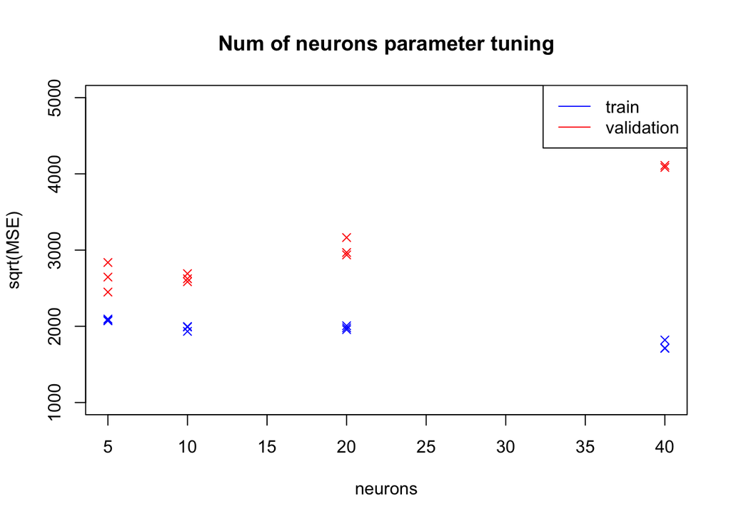

```r
plot(neur_seq, mse_test_neur, col = "red", ylim = c(1000, 5000), main = "Num of neurons parameter tuning", pch = 4, xlab = "neurons", ylab = "sqrt(MSE)")
points(neur_seq, mse_valid_neur, col = "blue", pch = 4)
legend("topright", legend = c("train","validation"), lty = c(1,1), col = c("blue", "red"))
```

## Два скрытых слоя

```r
set.seed(4537)

start_time <- Sys.time()

epochs <- 20
# nn2.car <- neuralnet(n5 ~ .,
#                 data = scaled_cars_train,
#                 algorithm = "rprop+",
#                 hidden = c(5, 5),
#                 stepmax = 1e+05,
#                 linear.output = TRUE,
#                 act.fct = "logistic",
#                 err.fct = "sse",
#                 startweights = NULL,
#                 rep = epochs,
#                 threshold = 0.2
#                 )
# end_time <- Sys.time()
# end_time - start_time

#saveRDS(nn2.car, "nn2_car.rds")
nn2.car <- readRDS("nn2_car.rds")
```

```r
nn2.test_prediction <- list(length = epochs)
nn2.test_err_curve <- numeric(length = epochs)
nn2.train_err_curve <- numeric(length = epochs)

for (i in 1:epochs) {
pr.nn <- predict(nn2.car, scaled_cars_test[,-5], rep = i)
nn2.test_prediction[[i]] <- pr.nn * (maxs[5] - mins[5]) + mins[5]
nn2.test_err_curve[i] <- sqrt(mean((cars_dum$price_usd[test_id] - nn2.test_prediction[[i]])^2))
nn2.train_err_curve[i] <- sqrt(mean(((nn2.car$net.result[[i]] * (maxs[5] - mins[5]) ) + mins[5] - cars_dum[train_id[-valid_id], 7])^2))
}
```

### Learning curve

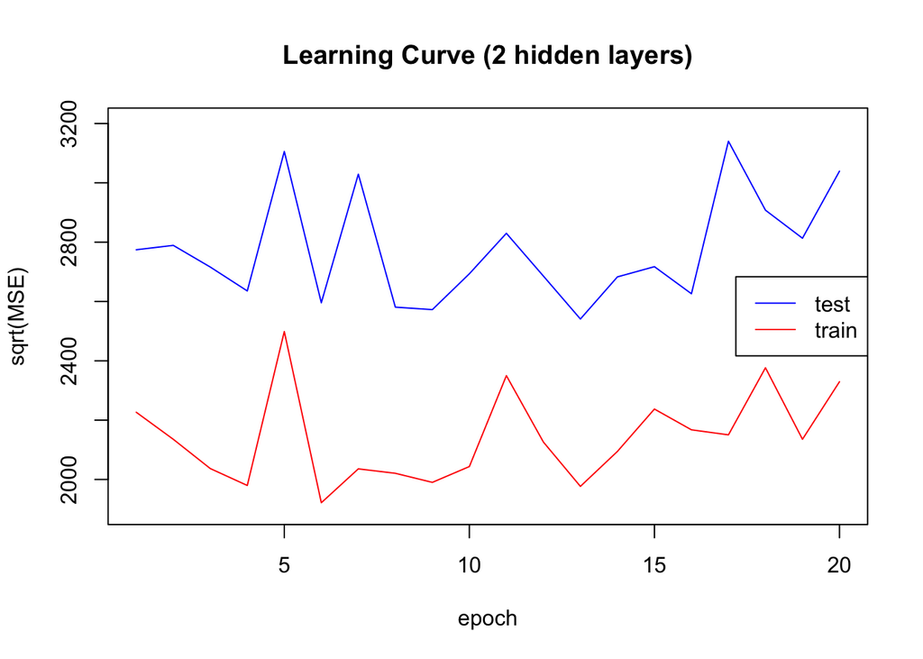

```r
plot(1:epochs, nn2.test_err_curve, col = "blue", main = "Learning Curve (2 hidden layers)", xlab = "epoch", ylab = "sqrt(MSE)", "l", ylim = c(1900, 3200))
lines(1:epochs, nn2.train_err_curve, col = "red")
legend("right", legend = c("test","train"), lty = c(1,1), col = c("blue", "red"))
```

```r
nn2.train_err <- nn2.train_err_curve[9]
nn2.test_err <- nn2.test_err_curve[9]
```

### Дополнительные эксперименты

#### Число нейронов

Узнаём на validation set и по одной эпохе.

```r
set.seed(44537)
epochs <- 1
neur_pairs <- list(c(5,5), c(10,10), c(10,5), c(20, 10))
# mse_valid_neur_pairs <- numeric(length = length(neur_pairs))
# mse_train_neur_pairs <- numeric(length = length(neur_pairs))
#
# for (i in 1:length(neur_pairs)) {
#     nn2.car_neurons <- neuralnet(n5 ~ .,
#                     data = scaled_cars_train,
#                     algorithm = "rprop+",
#                     hidden = neur_pairs[[i]],
#                     stepmax = 1e+05,
#                     linear.output = TRUE,
#                     act.fct = "logistic",
#                     err.fct = "sse",
#                     startweights = NULL,
#                     rep = epochs,
#                     threshold = 0.1
#                     )
#
#
#     pr.nn_neurons <- predict(nn2.car_neurons, scaled_cars_valid[,-5], rep = 1)
#     nnn.test_prediction <- pr.nn_neurons * (maxs[5] - mins[5]) + mins[5]
#     nnn.valid_err <- sqrt(mean((cars_dum$price_usd[train_id[valid_id]] - nnn.test_prediction)^2))
#     nnn.train_err <- sqrt(mean((nn2.car_neurons$net.result[[1]] * (maxs[5] - mins[5]) + mins[5]
#                                             - cars_dum[train_id[-valid_id], 7])^2))
#     mse_train_neur_pairs[i] <- nnn.train_err
#     mse_valid_neur_pairs[i] <- nnn.valid_err
# }

#saveRDS(mse_train_neur_pairs, "mse_train_neur_pairs.rds")
#saveRDS(mse_valid_neur_pairs, "mse_valid_neur_pairs.rds")
mse_train_neur_pairs <- readRDS("mse_train_neur_pairs.rds")
mse_valid_neur_pairs <- readRDS("mse_valid_neur_pairs.rds")
```

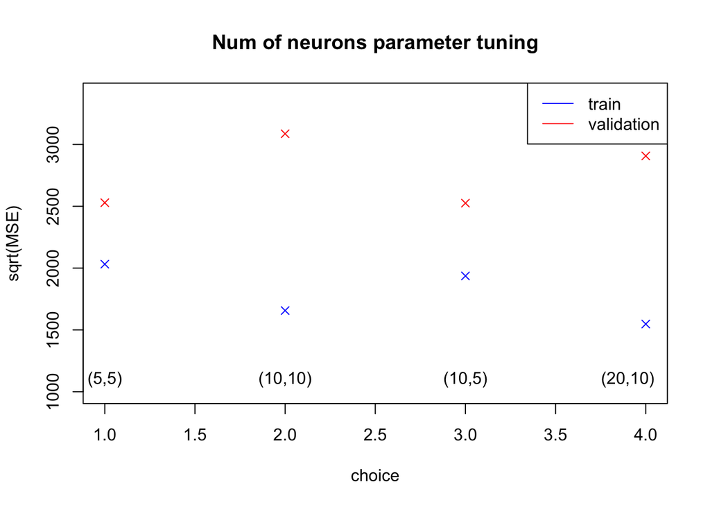

```r
plot(1:length(neur_pairs), mse_valid_neur_pairs, col = "red", ylim = c(1000, 3400), main = "Num of neurons parameter tuning", pch = 4, xlab = "choice", ylab = "sqrt(MSE)")
points(1:length(neur_pairs), mse_train_neur_pairs, col = "blue", pch = 4)
text(1, 1100,  "(5,5)")
text(2, 1100,  "(10,10)")
text(3, 1100,  "(10,5)")
text(3.9, 1100,  "(20,10)")
legend("topright", legend = c("train","validation"), lty = c(1,1), col = c("blue", "red"))
```

## Про метод

1. **Какая постановка задачи, что предполагается, что и почему оптимизируется (функция потерь), как оптимизируется?**

Регрессия, квадратичная потеря минимизируется.

2. **Какие параметры у метода: функция плюс соответствие теор.формул и параметров**

Наверх.

3. **Как подбирали параметры, на основе чего?**

Некоторые на основе общих рекомендаций, некоторые с помощью валидационного подхода

4. **Как справлялись с overfitting?**

Не совсем правильным способом, но с помощью правдоподобных рассуждений.

5. **Какой получили результат на cross-validation?**

Узнали, какие варианты числа нейронов получше, а какие похуже.

6. **Подтверждаете свое исходное объяснение, почему метод сработал хорошо/плохо**

Датасет достаточно сложный с точки зрения различных зависимостей, при этом крупный, поэтому предполагаю, что при хорошем выборе параметров можно получить результат, сопоставимый с результатом у случайных деревьев.

# Сравнительный анализ

**Таблица с корнями из MSE**

```r
table_comp <- cbind(linReg = c(lm.train_err, lm.test_err), linReg_log = c(lm_log.train_err, lm_log.test_err), randomFor = c(rf.train_err, rf.test_err), neuralNet_1 = c(nn1.train_err, nn1.test_err), neuralNet_2 = c(nn2.train_err, nn2.test_err))
rownames(table_comp) <- c("train", "test")
table_comp
```

```
##         linReg linReg_log randomFor neuralNet_1 neuralNet_2
## train 3315.739   2566.806  2317.378    2133.667    1990.249
## test  3540.138   2830.500  2367.587    2807.756    2572.573
```

## Графики предсказаний

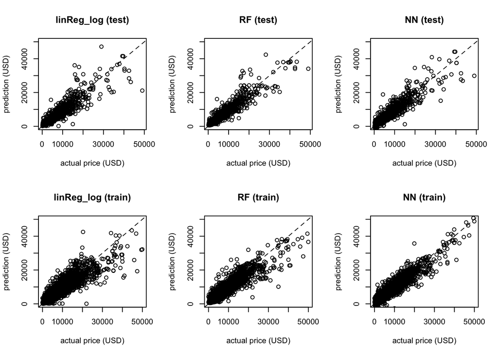

```r
par(mfrow = c(2,3))
plot(cars_dum$price_usd[test_id], exp(lm_log.car_predict), main = "linReg_log (test)", ylim = c(0,50000), xlab = "actual price (USD)", ylab = "prediction (USD)")
abline(a = 0, b = 1, lty = 2)
plot(cars_dum$price_usd[test_id], rf.car$test$predicted, main = "RF (test)", ylim = c(0,50000), xlab = "actual price (USD)", ylab = "prediction (USD)")
abline(a = 0, b = 1, lty = 2)
plot(cars_dum[test_id,7], nn2.test_prediction[[9]],  main = "NN (test)", ylim = c(0,50000), xlab = "actual price (USD)", ylab = "prediction (USD)")
abline(a = 0, b = 1, lty = 2)
plot(cars_dum$price_usd[train_id], exp(lm_log.car$fitted.values), main = "linReg_log (train)", ylim = c(0,50000), xlab = "actual price (USD)", ylab = "prediction (USD)")
abline(a = 0, b = 1, lty = 2)
plot(cars_dum$price_usd[train_id[-valid_id]], rf.car$predicted, main = "RF (train)", ylim = c(0,50000), xlab = "actual price (USD)", ylab = "prediction (USD)")
abline(a = 0, b = 1, lty = 2)
plot(cars_dum$price_usd[train_id[-valid_id]],  nn2.car$net.result[[9]] * (maxs[5] - mins[5]) + mins[5] , main = "NN (train)", ylim = c(0,50000), xlab = "actual price (USD)", ylab = "prediction (USD)")
abline(a = 0, b = 1, lty = 2)
```